# Predicting the Present

Gabrielle Martinez (Pace University)

6/23/2020

# Replicating Using Author’s Unadjusted Cleaned Data

## Load Data

```r
motor_vehicles <- read.csv('merged.csv')
motor_vehicles %>%
  mutate(Period = as.Date(Period)) -> motor_vehicles

motor_vehicles %>%
  mutate(last_month_sales = lag(sales, 1), last_year_sales = lag(sales, 12)) -> motor_vehicles
```

## Make the Baseline Model

```r
#Let yt be the log of the observation at time t
base_model <- lm(log(sales) ~ log(last_month_sales) + log(last_year_sales), data = motor_vehicles)

#summary(base_model)

tidy(base_model)
```

```
## # A tibble: 3 x 5
##   term                  estimate std.error statistic  p.value
##   <chr>                    <dbl>     <dbl>     <dbl>    <dbl>
## 1 (Intercept)              0.673    0.764      0.881 3.81e- 1
## 2 log(last_month_sales)    0.643    0.0733     8.78  3.59e-13
## 3 log(last_year_sales)     0.296    0.0728     4.06  1.18e- 4
```

```r
glance(base_model)
```

```
## # A tibble: 1 x 11
##   r.squared adj.r.squared  sigma statistic  p.value    df logLik   AIC   BIC
##       <dbl>         <dbl>  <dbl>     <dbl>    <dbl> <int>  <dbl> <dbl> <dbl>
## 1     0.719         0.711 0.0798      97.0 1.20e-21     3   89.1 -170. -161.
## # ... with 2 more variables: deviance <dbl>, df.residual <int>
```

## Make the Trends Model

```r
trends_model <- lm(log(sales) ~ log(last_month_sales) + log(last_year_sales) + suvs + insurance, data = motor_vehicles)

tidy(trends_model)
```

```
## # A tibble: 5 x 5
##   term                  estimate std.error statistic  p.value
##   <chr>                    <dbl>     <dbl>     <dbl>    <dbl>
## 1 (Intercept)             -0.458    0.784     -0.584 5.61e- 1
## 2 log(last_month_sales)    0.619    0.0632     9.81  5.09e-15
## 3 log(last_year_sales)     0.429    0.0654     6.56  6.45e- 9
## 4 suvs                     1.06     0.167      6.34  1.66e- 8
## 5 insurance               -0.530    0.152     -3.48  8.35e- 4
```

```r
glance(trends_model)
```

```
## # A tibble: 1 x 11
##   r.squared adj.r.squared  sigma statistic  p.value    df logLik   AIC   BIC
##       <dbl>         <dbl>  <dbl>     <dbl>    <dbl> <int>  <dbl> <dbl> <dbl>
## 1     0.818         0.808 0.0651      83.1 1.35e-26     5   106. -201. -186.
## # ... with 2 more variables: deviance <dbl>, df.residual <int>
```

## Plot in-sample forcasting

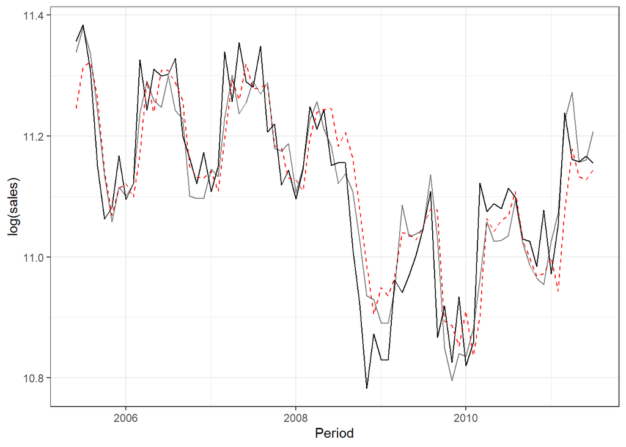

```r
motor_vehicles %>%
  add_predictions(base_model, "base") %>%
  add_predictions(trends_model, "trend") -> motor_vehicles_in_sample

motor_vehicles_in_sample %>%
  filter(Period >= "2005-06-01") %>%
  ggplot(aes(x=Period, y = log(sales))) +
  geom_line() +
  geom_line(aes(y=base), color = "red", linetype="dashed") +
  geom_line(aes(y=trend), alpha = .5)
```

## Out of Sample forecasting using Rolling window method

> “To check this, we use a rolling window forecast where we estimate the model using the data for periods k through t − 1 and then forecast yt using yt−1, yt−12, and the contemporaneous values of the Trends variables as predictors. Since the series is actually released 2 weeks after the end of each month, this gives us a meaningful forecasting lead. The value of k is chosen so that there are a reasonable number of observations for the first regression in the sequence. In this case we chose k = 17, which implied the forecasts start in 2005-06-01.” [(Choi & Varian, 2011)](http://people.ischool.berkeley.edu/~hal/Papers/2011/ptp.pdf)

Let’s start with the base model

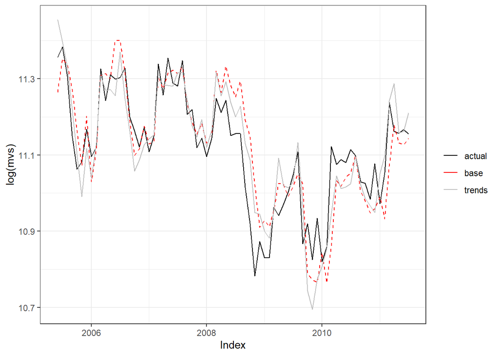

```r
#split the data 1-17 for first model

  #top_17_mv <-
  #  filter(motor_vehicles ,Period < "2005-06-01")

#train the first model

base_line_out <- lm(log(sales) ~ log(last_month_sales) + log(last_year_sales), data=motor_vehicles[1:17,])

trend_line_out <- lm(log(sales) ~ log(last_month_sales) + log(last_year_sales) + suvs + insurance, data=motor_vehicles[1:17,])

#tidy(model_01)
#glance(model_01)

#predictions <- add_row(
# add_predictions(motor_vehicles[17,], model_01, "base_pred")) #-> predictions

#predictions <- add_predictions(motor_vehicles[18,], model_01, "base_pred")

predictions <-  motor_vehicles[18,] %>% add_predictions(base_line_out, "base_pred") %>% add_predictions(trend_line_out, "trend_pred")


#for loop adding next month data to training split

rows <- 18:90

for (row in rows) {

  base_line_out <-
     lm(log(sales) ~ log(last_month_sales) + log(last_year_sales), data=motor_vehicles[1:row,])

  trend_line_out <-
    lm(log(sales) ~ log(last_month_sales) + log(last_year_sales) + suvs + insurance, data=motor_vehicles[1:row,])

 # predictions <- add_row(predictions, add_predictions(motor_vehicles[row+1,], model_01, "base_pred"))

  predictions <-
    add_row(predictions, add_predictions(motor_vehicles[row+1, ], base_line_out, "base_pred") %>% add_predictions(trend_line_out, "trend_pred"))

}


#plot
predictions %>%
  ggplot() +
  geom_line(aes(x = Period, y = log(sales), color = "actual")) +
  geom_line(aes(x = Period, y = base_pred, color = "base"), linetype = "dashed") +
  geom_line(aes(x = Period, y = trend_pred, color = "trends")) +
  scale_colour_manual("",
                      breaks = c("actual", "base", "trends"),
                      values = c("black", "red", "grey")) +
  ylab("log(mvs)")+
  xlab("Index")
```

Let’s calculate the Mean Absolute Error for the above.

```r
maebase <-
  mean(abs(predictions$base_pred - log(predictions$sales)))  #MAE for the baseline model
maetrends <-
  mean(abs(predictions$trend_pred - log(predictions$sales))) #MAE for the trends model

((maetrends - maebase)/maebase)*100
```

```
## [1] -10.66089
```

The MAE for the base model is 0.0634398 while the MAE for the trends model 0.0566766. There is a 10.66% improvement between the base and trends model. This is consistent with the paper’s results.

# Recreating the results using the original source data

> Census Data found [here](https://www.census.gov/econ/currentdata/export/csv?programCode=MARTS&timeSlotType=12&startYear=1992&endYear=2020&categoryCode=441&dataTypeCode=SM&geoLevelCode=US&adjusted=no&errorData=no&internal=false)

> Using Google Trends results from 1/1/2004 - 7/1/2011 found [here](https://trends.google.com/trends/explore?cat=467&date=2004-01-01%202011-07-01&geo=US) and [here](https://trends.google.com/trends/explore?cat=610&date=2004-01-01%202011-07-01&geo=US)

Let’s load in the data for cleaning and reformating

```r
census <- read.csv("census_data.csv")

census %>%
  mutate(Period = as.Date(Period, format= "%m/%d/%Y")) %>%
  rename("period"= "Period", "sales"="Value") -> census

#load trucks and suv trends data
trends_data_suv<- read.csv("trucks_suv_2011.csv")

trends_data_suv %>%
  rename("suv"="Geo..United.States") %>%
  mutate(Month = paste(Month, "-01", sep=""),
         Month = as.Date(Month, format="%Y-%m-%d"))-> trends_data_suv

inner_join(census, trends_data_suv, by=c("period"="Month")) -> motor_vehicles

#load auto insurance data
trends_insurance<- read.csv("insurance_2011.csv", F)

trends_insurance %>%
  rename("date"="V1","insurance"= "V2") %>%
  mutate(date = paste(date, "-01", sep=""),
         date = as.Date(date, format="%Y-%m-%d"))-> trends_insurance

inner_join(motor_vehicles, trends_insurance, by=c("period"="date")) -> motor_vehicles
```

### Remaking the in-sample models

```r
#adding lag columns

motor_vehicles %>%
  mutate(last_month_sales = lag(sales, 1), last_year_sales = lag(sales, 12)) -> motor_vehicles

#base model without trends data
base_model <- lm(log(sales) ~ log(last_month_sales) + log(last_year_sales), data = motor_vehicles)

tidy(base_model)
```

```
## # A tibble: 3 x 5
##   term                  estimate std.error statistic  p.value
##   <chr>                    <dbl>     <dbl>     <dbl>    <dbl>
## 1 (Intercept)              0.668    0.760      0.879 3.82e- 1
## 2 log(last_month_sales)    0.651    0.0728     8.94  1.75e-13
## 3 log(last_year_sales)     0.289    0.0722     3.99  1.49e- 4
```

```r
glance(base_model)
```

```
## # A tibble: 1 x 11
##   r.squared adj.r.squared  sigma statistic  p.value    df logLik   AIC   BIC
##       <dbl>         <dbl>  <dbl>     <dbl>    <dbl> <int>  <dbl> <dbl> <dbl>
## 1     0.721         0.714 0.0801      98.3 8.31e-22     3   88.8 -170. -160.
## # ... with 2 more variables: deviance <dbl>, df.residual <int>
```

```r
#trends model with trends data
trends_model <- lm(log(sales) ~ log(last_month_sales) + log(last_year_sales) + suv + insurance, data = motor_vehicles)

tidy(trends_model)
```

```
## # A tibble: 5 x 5
##   term                  estimate std.error statistic       p.value
##   <chr>                    <dbl>     <dbl>     <dbl>         <dbl>
## 1 (Intercept)            1.21      1.02         1.18 0.240
## 2 log(last_month_sales)  0.546     0.0790       6.91 0.00000000144
## 3 log(last_year_sales)   0.311     0.0722       4.31 0.0000496
## 4 suv                    0.0111    0.00275      4.03 0.000135
## 5 insurance             -0.00657   0.00217     -3.03 0.00333
```

```r
glance(trends_model)
```

```
## # A tibble: 1 x 11
##   r.squared adj.r.squared  sigma statistic  p.value    df logLik   AIC   BIC
##       <dbl>         <dbl>  <dbl>     <dbl>    <dbl> <int>  <dbl> <dbl> <dbl>
## 1     0.780         0.768 0.0722      65.6 1.40e-23     5   98.2 -184. -170.
## # ... with 2 more variables: deviance <dbl>, df.residual <int>
```

### Out of sample forcasting model

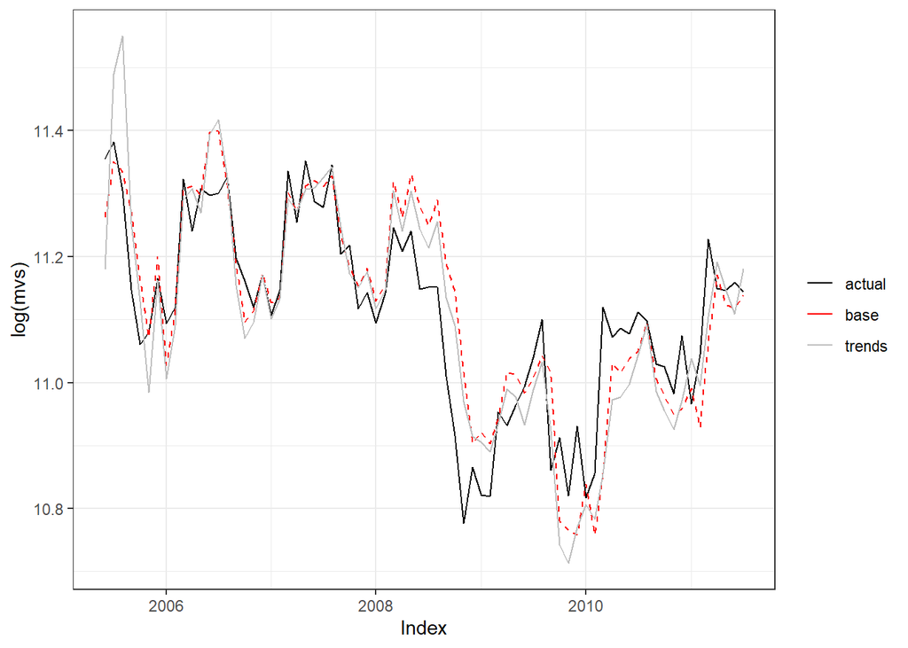

```r
#first model based on the first 17 months
base_line_out <- lm(log(sales) ~ log(last_month_sales) + log(last_year_sales), data=motor_vehicles[1:17,])

trend_line_out <- lm(log(sales) ~ log(last_month_sales) + log(last_year_sales) + suv + insurance, data=motor_vehicles[1:17,])

#tidy(trend_line_out)
#glance(trend_line_out)

predictions <-  motor_vehicles[18,] %>% add_predictions(base_line_out, "base_pred") %>% add_predictions(trend_line_out, "trend_pred")


#for loop for the rolling window

#mae_base <- c(mae(base_line_out, predictions))
#mae_trend <- c(mae(trend_line_out, predictions))

rows <- 18:90
for (row in rows) {

  base_line_out <-
     lm(log(sales) ~ log(last_month_sales) + log(last_year_sales), data=motor_vehicles[1:row,])

  trend_line_out <-
    lm(log(sales) ~ log(last_month_sales) + log(last_year_sales) + suv + insurance, data=motor_vehicles[1:row,])

  predictions <-
    add_row(predictions, add_predictions(motor_vehicles[row+1, ], base_line_out, "base_pred") %>% add_predictions(trend_line_out, "trend_pred"))

#  mae_base <- c(mae_base, mae(base_line_out, predictions))
#  mae_trend <- c(mae_trend, mae(trend_line_out, predictions))

}

#plot
predictions %>%
  ggplot() +
  geom_line(aes(x = period, y = log(sales), color = "actual")) +
  geom_line(aes(x = period, y = base_pred, color = "base"), linetype = "dashed") +
  geom_line(aes(x = period, y = trend_pred, color = "trends")) +
  scale_colour_manual("",
                      breaks = c("actual", "base", "trends"),
                      values = c("black", "red", "grey")) +
  ylab("log(mvs)")+
  xlab("Index")
```

### Calculating errors

```r
maebase <-
  mean(abs(predictions$base_pred - log(predictions$sales)))

maetrends <-
  mean(abs(predictions$trend_pred - log(predictions$sales)))

((maetrends - maebase)/maebase)*100
```

```
## [1] 7.212689
```

The MAE for the base model is 0.0636592 while the MAE for the trends model 0.0682508. There is a 7.21% greater error for the trends model compared to the base model. The paper describes how the trends model can be less accurate in the agrregate but more accurate at certain “turning points”. They use the 2008 recession as an example, perhaps suggesting that trends data would be more accurate than a simple model during extreme or unusal cases.

```r
# Calculate the MAE during recession (December 2007 through June 2009)

recession <- predictions %>% filter(period > '2007-11-01' & period <= '2009-06-01')

mae_base_re <- mean(abs(recession$base_pred - log(recession$sales)))

mae_trend_re <- mean(abs(recession$trend_pred - log(recession$sales)))

((mae_trend_re - mae_base_re) / mae_base_re) * 100
```

```
## [1] -21.8032
```

The MAE for the base model is 0.0890323 while the MAE for the trends model 0.0696204. There is a 21.80% improvement for the trends model compared to the base model. This is still fairly constant with the findings of the paper, which found a 20% improvement in accuracy.

## Expansion: Is this technique useful today?

Let’s use that same census data that includes May 2020 from earlier. And load in Google Trends data from 2004-2020

```r
trends_data_suv <- read.csv("trucks_suv.csv")
trends_insurance <- read.csv("auto_insurance.csv")

#reformat trends data

trends_data_suv %>%
  rename("suv"="Geo..United.States") %>%
  mutate(Month = paste(Month, "-01", sep=""),
         Month = as.Date(Month, format="%Y-%m-%d"))-> trends_data_suv

inner_join(census, trends_data_suv, by=c("period"="Month")) -> motor_vehicles

trends_insurance %>%
  rename("date"="Month","insurance"= "Geo..United.States") %>%
  mutate(date = paste(date, "-01", sep=""),
         date = as.Date(date, format="%Y-%m-%d"))-> trends_insurance

inner_join(motor_vehicles, trends_insurance, by=c("period"="date")) -> motor_vehicles

#filter instances where sales is blank June 2020 not yet available
motor_vehicles %>%
  filter(!is.na(sales)) -> motor_vehicles


#adding lag columns
motor_vehicles %>%
  mutate(last_month_sales = lag(sales, 1), last_year_sales = lag(sales, 12)) -> motor_vehicles
```

### In-sample model

```r
#base model without trends data
base_model <- lm(log(sales) ~ log(last_month_sales) + log(last_year_sales), data = motor_vehicles)

tidy(base_model)
```

```
## # A tibble: 3 x 5
##   term                  estimate std.error statistic  p.value
##   <chr>                    <dbl>     <dbl>     <dbl>    <dbl>
## 1 (Intercept)            -0.0395    0.334     -0.118 9.06e- 1
## 2 log(last_month_sales)   0.544     0.0454    12.0   9.93e-25
## 3 log(last_year_sales)    0.460     0.0474     9.71  3.20e-18
```

```r
glance(base_model)
```

```
## # A tibble: 1 x 11
##   r.squared adj.r.squared  sigma statistic  p.value    df logLik   AIC   BIC
##       <dbl>         <dbl>  <dbl>     <dbl>    <dbl> <int>  <dbl> <dbl> <dbl>
## 1     0.864         0.863 0.0739      581. 1.02e-79     3   221. -434. -421.
## # ... with 2 more variables: deviance <dbl>, df.residual <int>
```

```r
#trends model with trends data
trends_model <- lm(log(sales) ~ log(last_month_sales) + log(last_year_sales) + suv + insurance, data = motor_vehicles)

tidy(trends_model)
```

[output not shown]

```r
glance(trends_model)
```

```
## # A tibble: 1 x 11
##   r.squared adj.r.squared  sigma statistic  p.value    df logLik   AIC   BIC
##       <dbl>         <dbl>  <dbl>     <dbl>    <dbl> <int>  <dbl> <dbl> <dbl>
## 1     0.869         0.867 0.0728      401. 1.21e-79     4   224. -438. -422.
## # ... with 2 more variables: deviance <dbl>, df.residual <int>
```

### Plot in-sample forecasting

```r
motor_vehicles %>%
  add_predictions(base_model, "base") %>%
  add_predictions(trends_model, "trend") -> motor_vehicles_in_sample
```

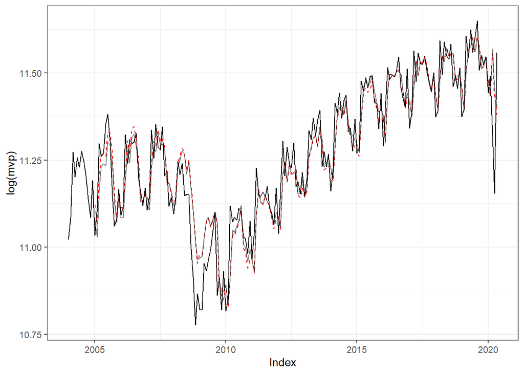

```r
motor_vehicles_in_sample %>%
  ggplot(aes(x=period, y = log(sales))) +
  geom_line() +
  geom_line(aes(y=base), color = "red", linetype="dashed") +
  geom_line(aes(y=trend), alpha = .5) +
  xlab("Index") +
  ylab("log(mvp)")
```

The in-sample model predicts a rise in sales when in actuality, sales have sharply declined in the beginning of 2020, likely due to the Covid-19 pandemic. I thought using trends would have more accurately predicted the dip in sales but it is rather the opposite. Let’s see how our out-of-sample forecasting model fairs.

### Out of sample model

```r
#first model based on the first 17 months
base_line_out <- lm(log(sales) ~ log(last_month_sales) + log(last_year_sales), data=motor_vehicles[1:17,])

trend_line_out <- lm(log(sales) ~ log(last_month_sales) + log(last_year_sales) + suv + insurance, data=motor_vehicles[1:17,])

#tidy(trend_line_out)
#glance(trend_line_out)

predictions <-  motor_vehicles[18,] %>% add_predictions(base_line_out, "base_pred") %>% add_predictions(trend_line_out, "trend_pred")
#for loop for the rolling window

#mae_base <- c(log(predictions$base_pred) - log(predictions$sales))
#mae_trend <- c(log(predictions$trend_pred) - log(predictions$sales))

rows <- 18:196
for (row in rows) {

  base_line_out <-
     lm(log(sales) ~ log(last_month_sales) + log(last_year_sales), data=motor_vehicles[1:row,])

  trend_line_out <-
    lm(log(sales) ~ log(last_month_sales) + log(last_year_sales) + suv + insurance, data=motor_vehicles[1:row,])

  predictions <-
    add_row(predictions, add_predictions(motor_vehicles[row+1, ], base_line_out, "base_pred") %>% add_predictions(trend_line_out, "trend_pred"))

  #mae_base <- c(log(predictions$base_pred) - log(predictions$sales))
  #mae_trend <- c(log(predictions$trend_pred) - log(predictions$sales))

}
```

[output not shown]

[output cut: 481 more lines]

[output not shown]

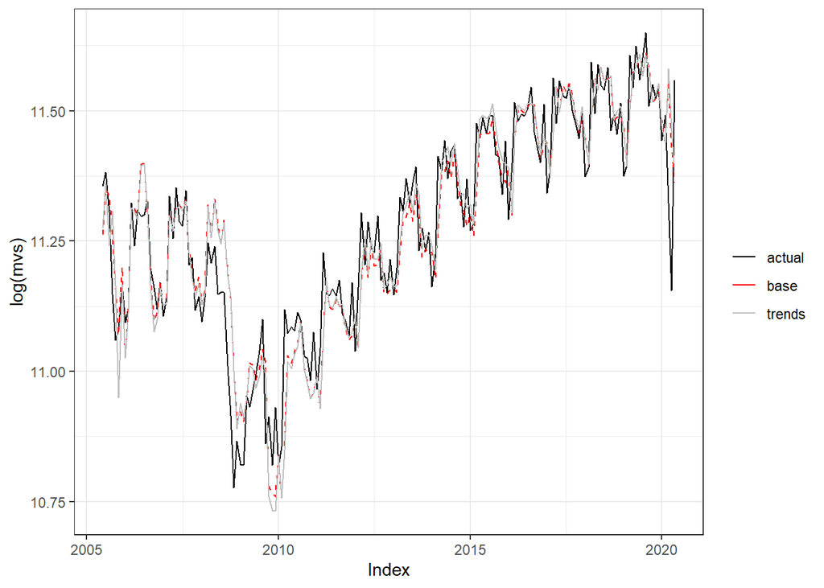

```r
#plot
predictions %>%
  ggplot() +
  geom_line(aes(x = period, y = log(sales), color = "actual")) +
  geom_line(aes(x = period, y = base_pred, color = "base"), linetype = "dashed") +
  geom_line(aes(x = period, y = trend_pred, color = "trends")) +
  scale_colour_manual("",
                      breaks = c("actual", "base", "trends"),
                      values = c("black", "red", "grey")) +
  ylab("log(mvs)")+
  xlab("Index")
```

### Calculating the error

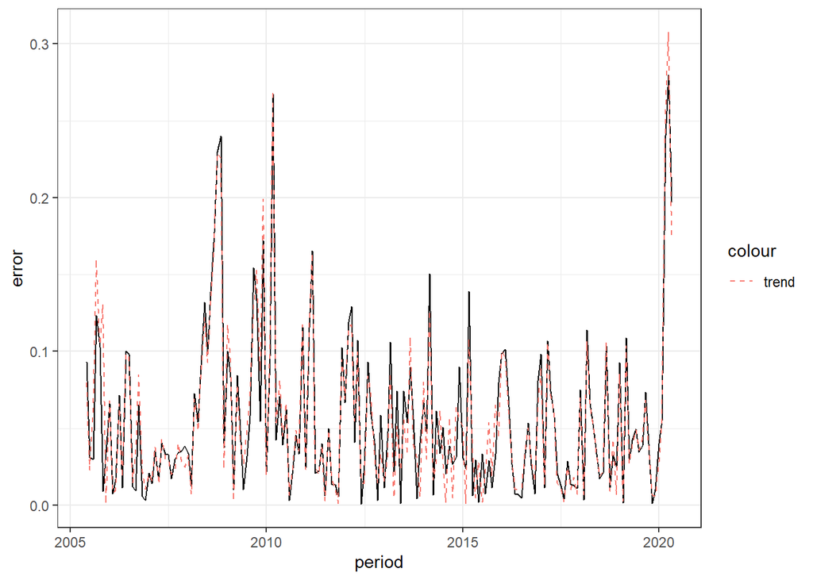

```r
#data.frame(predictions, mae_base, mae_trend)

predictions %>%
  mutate(mae_base = abs(predictions$base_pred - log(predictions$sales))) %>%
  mutate(mae_trend = abs(predictions$trend_pred - log(predictions$sales))) %>%
  ggplot(aes(x=period, y=mae_base)) +
  geom_line(aes(color="base"), color = "black") +
  geom_line(aes(x=period, y=mae_trend, color="trend"), linetype = "dashed") +
  ylab("error")
```

We see that the error of the two models are very close to each other and both have trouble predicting the recent dip in the sales due to Covid-19 and subsisiquent lockdown.

```r
maebase <-
  mean(abs(predictions$base_pred - log(predictions$sales)))

maetrends <-
  mean(abs(predictions$trend_pred - log(predictions$sales)))

((maetrends - maebase)/maebase)*100
```

```
## [1] 0.02178698
```

```r
# Calculate the MAE during recession (December 2007 through June 2009)

recession <- predictions %>% filter(period > '2007-11-01' & period <= '2009-06-01')

mae_base_re <- mean(abs(recession$base_pred - log(recession$sales)))

mae_trend_re <- mean(abs(recession$trend_pred - log(recession$sales)))

((mae_trend_re - mae_base_re) / mae_base_re) * 100
```

```
## [1] -4.008685
```

```r
covid19 <- predictions %>% filter(period >= '2020-03-01')

mae_base_re <- mean(abs(covid19$base_pred - log(covid19$sales)))

mae_trend_re <- mean(abs(covid19$trend_pred - log(covid19$sales)))

((mae_trend_re - mae_base_re) / mae_base_re) * 100
```

```
## [1] 3.351755
```